# Chapter 12: Multivariate Regression

Today’s class will be based on [Chapter 12: “Multiple Regression”](https://davidkane9.github.io/PPBDS/12-multiple-regression.html). Have you read it? We will be using data on college characteristics from the IPEDS Database and the Scorecard created by the Department of Education, gathered via the [Opportunity Insights](https://opportunityinsights.org/) project. The codebook with explanations for each variable is [here](https://opportunityinsights.org/wp-content/uploads/2018/04/Codebook-MRC-Table-10.pdf). We will be trying to figure out what characteristics of a college are associated with the 2011 median income of students, `earnings`, 10 years after they graduate. The other data — `faculty`, the average faculty salary; `sat`, the average SAT score; `tier`, the type of college; `public`, the private/public status; and `price`, tuition — is reported as of 2001.

### Scene 1

**Prompt:** Recall the three common steps of exploring a new dataset: 1) looking at the raw data, 2) computing summary statistics, and 3) creating visualizations of the data. Start this process. Useful commands to use here: `glimpse()`,`sample_n`, and `skim` (from the skimr package). What observations are surprising? (Hints: Look at extremes, especially for the key variable you are interested in. Hint at the data for the schools you know.)

```r
glimpse(x)
```

```
## Observations: 797
## Variables: 8
## $ name      <chr> "Abilene Christian University", "Adelphi University", "Agne…
## $ tier      <dbl> 6, 6, 4, 5, 5, 6, 6, 6, 6, 6, 6, 6, 6, 6, 4, 2, 8, 6, 5, 6,…
## $ tier_name <chr> "Selective private", "Selective private", "Highly selective…
## $ public    <dbl> 0, 0, 0, 1, 1, 0, 0, 0, 0, 0, 0, 0, 0, 0, 0, 0, 0, 0, 1, 0,…
## $ earnings  <dbl> 40200.00, 50600.00, 39400.00, 27800.00, 32700.00, 52200.00,…
## $ sat       <dbl> 1100.00, 1065.00, 1185.00, 800.00, 900.00, 1010.00, 1150.00…
## $ faculty   <dbl> 48039.76, 55523.10, 56078.15, 45691.52, 45164.08, 45315.07,…
## $ price     <dbl> 10910.000, 15690.000, 16745.000, 2520.000, 2398.000, 14778.…
```

```r
x %>%
sample_n(size = 5)
```

```
## # A tibble: 5 x 8
##   name             tier tier_name            public earnings   sat faculty price
##   <chr>           <dbl> <chr>                 <dbl>    <dbl> <dbl>   <dbl> <dbl>
## 1 Wheaton Colleg…     4 Highly selective pr…      0    42600 1315   58835. 15540
## 2 Kendall College    10 Four-year for-profit      0    40500  972.  40869. 12150
## 3 Saint Louis Co…     8 Nonselective four-y…      0   111600 1206.  55336. 13395
## 4 Cabrini College     6 Selective private         0    42700  955   39998. 16900
## 5 Southern Conne…     5 Selective public          1    41700  925   64391.  3850
```

```r
skim(x)
```

Data summary

| Name | x |
| --- | --- |
| Number of rows | 797 |
| Number of columns | 8 |
| _______________________ |  |
| Column type frequency: |  |
| character | 2 |
| numeric | 6 |
| ________________________ |  |
| Group variables | None |

**Variable type: character**

| skim_variable | n_missing | complete_rate | min | max | empty | n_unique | whitespace |
| --- | --- | --- | --- | --- | --- | --- | --- |
| name | 0 | 1 | 11 | 141 | 0 | 797 | 0 |
| tier_name | 0 | 1 | 8 | 45 | 0 | 10 | 0 |

**Variable type: numeric**

| skim_variable | n_missing | complete_rate | mean | sd | p0 | p25 | p50 | p75 | p100 | hist |
| --- | --- | --- | --- | --- | --- | --- | --- | --- | --- | --- |
| tier | 0 | 1 | 5.27 | 1.46 | 1.00 | 5.00 | 6.00 | 6.00 | 10.0 | ▁▁▇▁▁ |
| public | 0 | 1 | 0.32 | 0.47 | 0.00 | 0.00 | 0.00 | 1.00 | 1.0 | ▇▁▁▁▃ |
| earnings | 0 | 1 | 45129.97 | 10694.32 | 25500.00 | 38400.00 | 43200.00 | 49200.00 | 116400.0 | ▇▆▁▁▁ |
| sat | 0 | 1 | 1080.27 | 128.87 | 775.00 | 990.00 | 1060.00 | 1160.00 | 1520.0 | ▂▇▆▂▁ |
| faculty | 0 | 1 | 55207.37 | 13491.15 | 22043.62 | 46128.28 | 52828.56 | 63393.43 | 116117.4 | ▂▇▃▁▁ |
| price | 0 | 1 | 12168.56 | 7214.09 | 1376.00 | 4160.00 | 12950.00 | 17336.00 | 26746.0 | ▇▃▇▅▃ |

### Scene 2

**Prompt:** What’s the correlation between the average faculty salary in 2001 and the median income of students 10 years after entering? What’s the correlation between the average SAT scores in 2001 and the median income of students 10 years after entering? Find these by doing two separate correlations first, and then making a correlation matrix (instructions in the book).

```r
x %>%
  summarize(correlation = cor(faculty, earnings)) %>%
  pull(correlation)
```

```
## [1] 0.6737729
```

```r
x %>%
  summarize(correlation = cor(sat, earnings)) %>%
  pull(correlation)
```

```
## [1] 0.6041897
```

```r
x %>%
  select(earnings, faculty, sat) %>%
  cor()
```

```
##           earnings   faculty       sat
## earnings 1.0000000 0.6737729 0.6041897
## faculty  0.6737729 1.0000000 0.6359926
## sat      0.6041897 0.6359926 1.0000000
```

### Scene 3

**Prompt:** Visualize the relationships between the outcome variable (`earnings`) and the two key numerical explanatory variables (`faculty` and `sat`), one at a time. Create a ggplot for each showing the line of best fit.

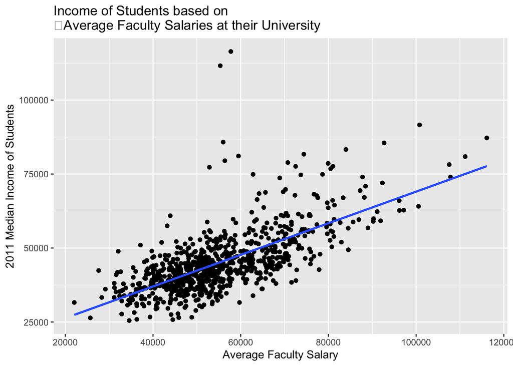

```r
x %>%
  ggplot(aes(faculty, earnings)) +
geom_point() +
geom_smooth(method = "lm", se = FALSE) +
  labs(x = "Average Faculty Salary",
       y = "2011 Median Income of Students",
       title = "Income of Students based on
    Average Faculty Salaries at their University")
```

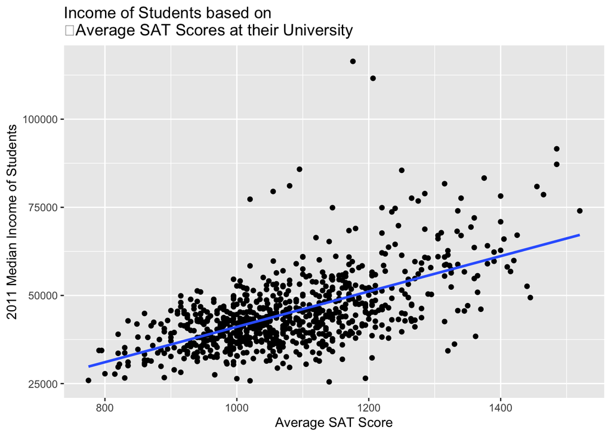

```r
x %>%
  ggplot(aes(sat, earnings)) +
geom_point() +
geom_smooth(method = "lm", se = FALSE) +
  labs(x = "Average SAT Score",
    y = "2011 Median Income of Students",
       title = "Income of Students based on
    Average SAT Scores at their University")
```

### Scene 4

**Prompt:** Now let’s quantify these relationships between the two explanatory variables and the outcome variable. Fit a multiple regression model for `earnings` using `sat` and `faculty` as the explanatory variables. Write a bullet point interpreting each of the three values in the estimate column. Do not use any interaction terms in the regression (yet).

```r
earnings_model <- lm(earnings ~ sat + faculty, data = x)

earnings_model %>%
  tidy(conf.int = TRUE) %>%
  select(term, estimate, conf.low, conf.high)
```

```
## # A tibble: 3 x 4
##   term         estimate  conf.low conf.high
##   <chr>           <dbl>     <dbl>     <dbl>
## 1 (Intercept) -2591.    -7092.     1910.
## 2 sat            24.5      19.2      29.7
## 3 faculty         0.385     0.335     0.436
```

### Scene 5

**Prompt:** Give a quick tour of your final project to the other students in your group. We will spend 10 minutes on this. Each student should, therefore, spend about N/10 minutes presenting. No worries if your project is a mess! No worries if the Shiny app does not work! We just want to have some useful conversations. Start with a quick one minute overview of your project. Then perhaps show one key plot or table which you have already created. I reserve the right to cold call a student and have her explain a classmate’s project.

### Scene 6

**Prompt:** Imagine that you are the university president. There’s a global pandemic that is causing serious financial damage to the school endowment, and in response, you want to cut the financial aid budget. However, because many academically talented students will go to whichever school gives them the best financial aid package, slashing the financial aid budget will cause the average SAT score to decrease from 1400 to 1300. Apply the Rubin Causal Model to frame the causal effect of this policy change on the median earnings of students 10 years from now. Write down the units, the treatments, and the outcomes. Define the causal effect of the policy change on median earnings. What is the fundamental problem of causal inference? What must you assume for this causal model to make a causal claim?

Applying the Rubin Causal Model to this dataset:

Unit: School/college

Treatment: Cutting the financial aid budget (or average SAT score)

Outcomes: Earnings of students 10 years after they enter college

Fundamental problem of causal inference: We cannot know the outcomes for each university under each treatment, because only one option can actually occur.

In order for this to be a causal claim, the treatment should be randomized to minimize confounding factors.

### Scene 7

**Prompt:** Recall the model we made in Scene 4. Use that model to make a prediction. Consider a school with average faculty salary of $50,000 and average SAT of 1400. What would the the median student’s earnings be 10 years from now? Although there are fancier ways of doing this in R — check out the `predict()` function — you should use the simple approach of using the regression estimates and then plugging in the appropriate values. Then, what would happen if a change in financial aid were to drop the average SAT score to 1300? What would you forecast earnings to be in that case? Putting the two together: What is the causal effect of the drop in SAT? Do you believe that? That is, if you were the university president, would you believe that forecast?

### Scene 8

**Prompt:** Now that we have our regression model using two numerical explanatory variables, let’s find the fitted values and residuals for the model using `augment()`. What do the fitted values and residuals mean, in terms of where they appear in a fitted line graph? Take a look at the biggest residuals, both positive and negative. What causes them? What is the model missing? How might we improve the model?

### Scene 9

**Prompt:** Now that we have explored the relationships between two numerical explanatory variables and the outcome variable, let’s look at a model that involves using one categorical variable `public` and one numerical explanatory variable `price` to explain the median earnings variable. We will explore a specific type of multiple regression model called an **interaction model** in this scene. `public` is 0 if the school is private and 1 if it is not.

First, fit the interaction regression model using the `lm()`. Then, retrieve the regression estimates, including the upper and lower bounds for the confidence intervals. Interpret the meaning of each of the estimates.

### Scene 10

**Prompt:** In the previous scene, we generated the confidence intervals using `tidy(conf.int = TRUE)` (if you haven’t, go back and do so now). Let’s check those confidence intervals by doing our own bootstrapping. Set `reps = 100` to save processing time. Hints: `unnest()`, `group_by()`, and `summarize()` are useful here.

How do the confidence intervals from bootstrapping compare to the ones we found in the previous scene? Provide a one sentence Bayesian interpretation and a one sentence Frequentist interpretation.

### Scene 11

**Prompt:** Now that we have our regression model using one numerical and one categorical explanatory variables, let’s visualize the interaction model using `ggplot2`. Set the colors to represent public vs. private xs. Hint: Be sure to make the `public` variable into a factor first.

### Scene 12

**Prompt:** Now let’s use the regression model results to make predictions. What would be the predicted value of median earnings for a private university with a sticker price of $20,000? Plot this as an intersection of a vertical line and the relevant line of best fit on the graph of the interaction model you made in the previous scene.

### Scene 13

**Prompt:** Now let’s go back to the two numerical explanatory variables that we explored earlier, `faculty` and `sat`, to understand variation in `earnings`. How well do these two variables explain the median earnings of students for each `tier` of x? The `tier` describes different combinations of college selectivity and type of college. We can model this using `map_*` functions and list columns. First, filter out all NA values for each explanatory variable. Then, use `map` to create models for each tier.

### Scene 14

**Prompt:** To best visualize the variation in the explanatory power of these two variables for the median student earnings for different tiers of xs, let’s plot them using error bars to show the confidence intervals for each tier of x. For which tiers of schools are these two explanatory variables best suited for predicting student earnings? Hint: Make sure that you specify the `tier` variable as a factor variable to make the x-axis tick marks more legible.

### Challenge Problem: Scene 15

**Prompt:** Make a `gganimate` plot that shows how a `loess` curve is fitted to a scatterplot of `sat` scores and `earnings`. Replicate this animation (or make it even better!): https://rpubs.com/amytan/satscoresandearnings